# Plotting with `ggplot2`

Ye Sun

2/21/2021

**A more refined version of this tutorial has now been included in our [COMM3710 R Book](https://sarakyeo.github.io/COMM-3710-bookdown/docs/ggplot2.html). You can also view this tutorial there.**

We start by loading the required packages.

```r
#Recommended to just install and load "tidyverse". It contains `ggplot2` and other useful packages.
library(tidyverse) #you need to install it first if you haven't. install.packages("tidyverse")
```

## Basics

Building `ggplot` graphics is typically an iterative process. We start by defining the data set that we’ll use `(data = )`, specify the axes `(aes())`, and choose the type of graph `geom`. We’ll explain each step below:

1. Use the `data =` argument to specify which data frame you are using to build the plot:

```r
ggplot(data = name_of_your_dataframe)
```

Please note that the word “data” in `(data = )` is an argument and should not be replaced. If your data frame is named `utilities`, this line should be `ggplot(data = utilities)`

2. Next, what are the variables you are plotting? Use `(aes)` – aesthetics – to select what variable is to place on the x-axis and which on the y-axis. Note that you are adding this element to the content inside the parentheses of `ggplot()`. To continue with Step 1, we have:

```r
ggplot(data = name_of_your_data, aes(x = variable_name_x, y = variable_name_y))
```

Make sure you close all the parentheses correctly – it’s a common error in R.

If you are only working with only one variable (e.g., getting the histogram of one variable), you will only need to specify the `x =` argument.

3. Next, we tell R what type of graph we’d like to make – points, lines, bars, histograms, etc. – by adding the `geoms` layer. This layer is outside the parentheses of `ggplot()` and is connected by a `+` sign.

If we would like the relationship between two variables to be represented by a scatterplot, we can simply add `geom_point()`.

```r
ggplot(data = name_of_your_data, aes(x = variable_name_x, y = variable_name_y)) +
         geom_point()
```

If we are plotting the histogram of one variable, we add `geom_histogram()`:

```r
ggplot(data = name_of_your_data, aes(x = variable_name_x)) +
         geom_histogram()

##This is slightly different than the exact commands used in the video but more intuitive following the logic in this instruction.
```

For a bar plot, the `geom` specification is `geom_bar()`.

**Important:**

The `+` sign used to add layers must be placed at the end of each line containing a layer. If, instead, the `+` sign is added in the line before the other layer, ggplot2 will not add the new layer and will return an error message.

```r
# This is the correct way of adding layers
ggplot( .... ) +
        geom_point()

# This will give you an error message
ggplot( .... )
       + geom_point()
```

## An illustration

We briefly illustrate the process with a fake data set [“quiz.csv”](http://yesuncomm.github.io/comm3710/files/quiz.csv). It contains the grades for Quiz 1 and Quiz 2 for 120 students (Data are simulated – not real!). There are three variables: `id` (student id), `quiz1` (Grade for Quiz 1), and `quiz2` (grade for Quiz 2).

First, make sure you set the working directory correctly on your computer and load the packages.

Download this [data set](http://yesuncomm.github.io/comm3710/files/quiz.csv) and read it into your R. I’ll just call this data frame `quiz`.

```r
quiz <- read.csv("quiz.csv")
```

I’m interested in seeing the distribution of grades for Quiz 1, which calls for a histogram.

To better understand what work R is doing step by step, you can run these lines one at a time and look at what happens in your RStudio “Plots” panel after each step.

`ggplot(data = quiz)`  
`ggplot(data = quiz, aes(x = quiz1))`  
`ggplot(data = quiz, aes(x = quiz1)) + geom_histogram()`

The complete command should be:

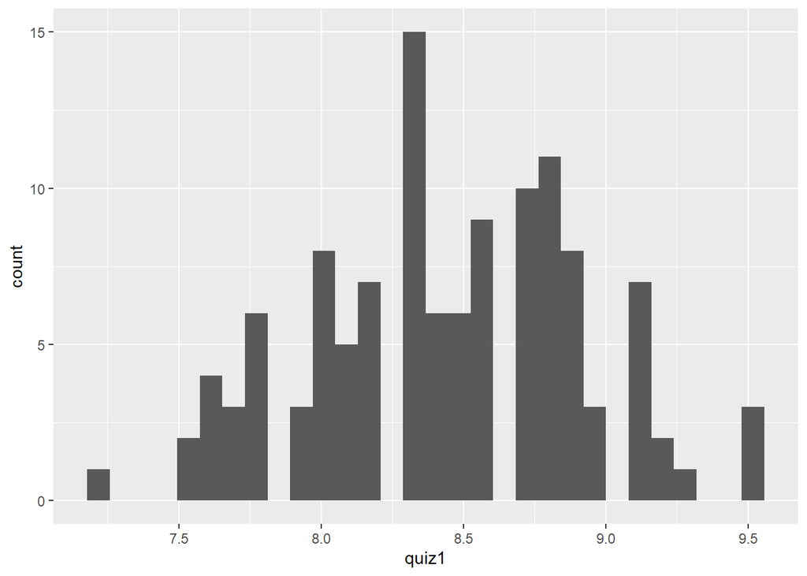

```r
ggplot(data = quiz, aes(x = quiz1)) +
  geom_histogram()
```

You can do the same for Quiz 2 grades:

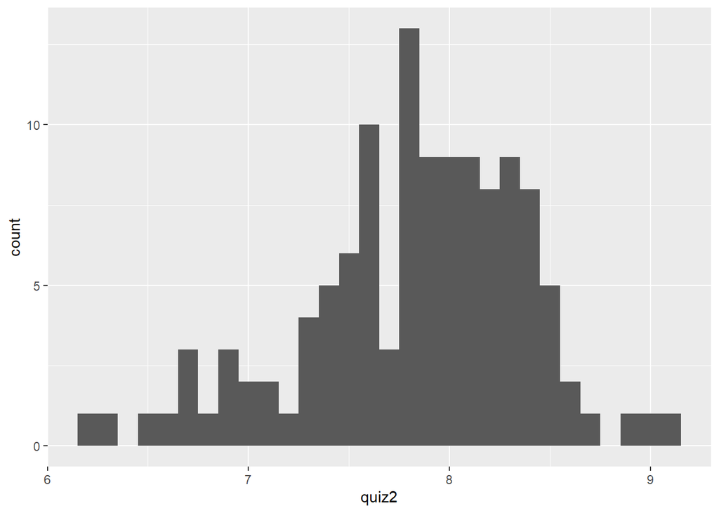

```r
ggplot(data = quiz, aes(x = quiz2)) +
  geom_histogram()
```

What if we want to see whether there is a relationship between Quiz 1 and Quiz 2 scores? As you could imagine, these two should be positively correlated – meaning that as one goes up, the other should also go up in general. We use a **scatterplot** to depict the relationship between two quantitative variables.

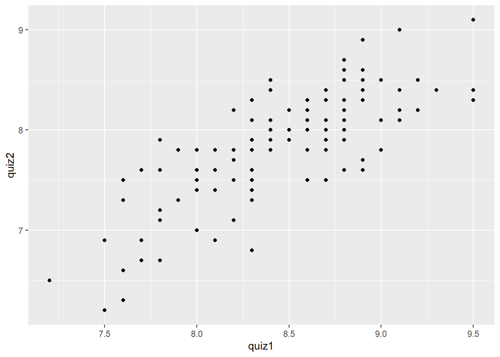

```r
ggplot(data = quiz, aes(x = quiz1, y = quiz2)) +
  geom_point()
```

Now I’m getting more ambitious – let’s label the two axes and add a title!

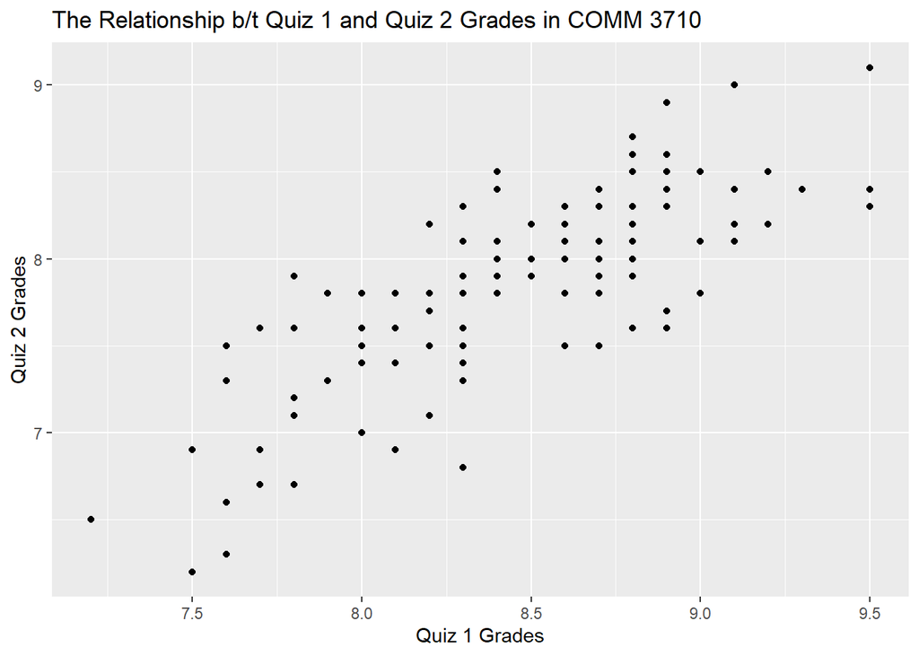

```r
ggplot(data = quiz, aes(x = quiz1, y = quiz2)) +
  geom_point() +
  labs(x = 'Quiz 1 Grades',
       y = 'Quiz 2 Grades',
       title = 'The Relationship b/t Quiz 1 and Quiz 2 Grades in COMM 3710')
```